# Exploratory Data Analysis (Coursera)

## The Process of Making a Plot

When making a plot one must first make a few considerations (not necessarily in this order):

- Where will the plot be made? On the screen? In a file?
- How will the plot be used?
  - Is the plot for viewing temporarily on the screen?
  - Will it be presented in a web browser?
  - Will it eventually end up in a paper that might be printed?
  - Are you using it in a presentation?
- Is there a large amount of data going into the plot? Or is it just a few points?
- Do you need to be able to dynamically resize the graphic?

## The Process of Making a Plot

- What graphics system will you use: base, lattice, or ggplot2? These generally cannot be mixed.
- Base graphics are usually constructed piecemeal, with each aspect of the plot handled separately through a series of function calls; this is often conceptually simpler and allows plotting to mirror the thought process
- Lattice graphics are usually created in a single function call, so all of the graphics parameters have to specified at once; specifying everything at once allows R to automatically calculate the necessary spacings and font sizes.
- ggplot2 combines concepts from both base and lattice graphics but uses an independent implementation

We focus on using the **base plotting system** to create graphics on the **screen device**.

## Base Graphics

Base graphics are used most commonly and are a very powerful system for creating 2-D graphics.

- There are two *phases* to creating a base plot
  - Initializing a new plot
  - Annotating (adding to) an existing plot
- Calling `plot(x, y)` or `hist(x)` will launch a graphics device (if one is not already open) and draw a new plot on the device
- If the arguments to `plot` are not of some special class, then the *default* method for `plot` is called; this function has *many* arguments, letting you set the title, x axis label, y axis label, etc.
- The base graphics system has *many* parameters that can set and tweaked; these parameters are documented in `?par`; it wouldn’t hurt to try to memorize this help page!

## Simple Base Graphics: Histogram

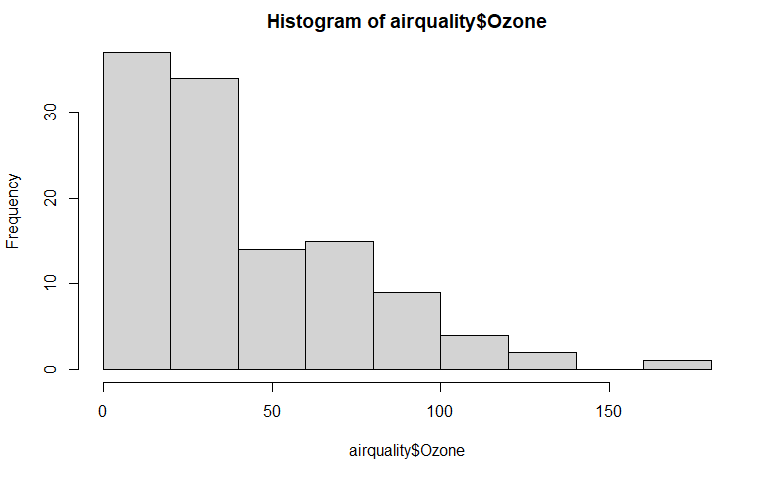

```r
library(datasets)
hist(airquality$Ozone)  ## Draw a new plot
```

## Simple Base Graphics: Scatterplot

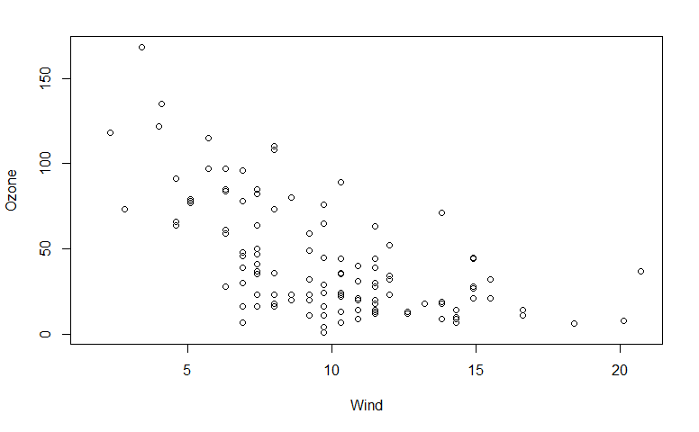

```r
library(datasets)
with(airquality, plot(Wind, Ozone))
```

## Simple Base Graphics: Boxplot

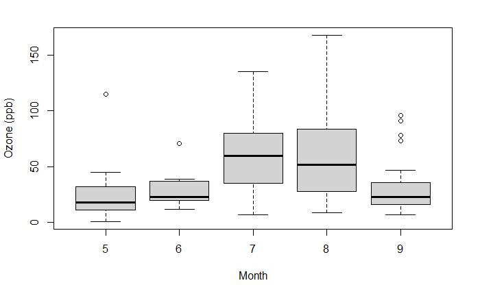

```r
library(datasets)
airquality <- transform(airquality, Month = factor(Month))
boxplot(Ozone ~ Month, airquality, xlab = "Month", ylab = "Ozone (ppb)")
```

## Some Important Base Graphics Parameters

Many base plotting functions share a set of parameters. Here are a few key ones:

- `pch`: the plotting symbol (default is open circle) - plotting character
- `lty`: the line type (default is solid line), can be dashed, dotted, etc.
- `lwd`: the line width, specified as an integer multiple
- `col`: the plotting color, specified as a number, string, or hex code; the `colors()` function gives you a vector of colors by name
- `xlab`: character string for the x-axis label
- `ylab`: character string for the y-axis label

## Some Important Base Graphics Parameters

The `par()` function is used to specify *global* graphics parameters that affect all plots in an R session. These parameters can be overridden when specified as arguments to specific plotting functions.

- `las`: the orientation of the axis labels on the plot
- `bg`: the background color
- `mar`: the margin size
- `oma`: the outer margin size (default is 0 for all sides)
- `mfrow`: number of plots per row, column (plots are filled row-wise)
- `mfcol`: number of plots per row, column (plots are filled column-wise)

## Some Important Base Graphics Parameters

Default values for global graphics parameters

## Some Important Base Graphics Parameters

Default values for global graphics parameters

```r
par("bg")
```

```
[1] "white"
```

```r
par("mar")
```

[output not shown]

```r
par("mfrow")
```

```
[1] 1 1
```

## Base Plotting Functions

- `plot`: make a scatterplot, or other type of plot depending on the class of the object being plotted
- `lines`: add lines to a plot, given a vector x values and a corresponding vector of y values (or a 2-column matrix); this function just connects the dots
- `points`: add points to a plot
- `text`: add text labels to a plot using specified x, y coordinates
- `title`: add annotations to x, y axis labels, title, subtitle, outer margin
- `mtext`: add arbitrary text to the margins (inner or outer) of the plot
- `axis`: adding axis ticks/labels

## Base Plot with Annotation

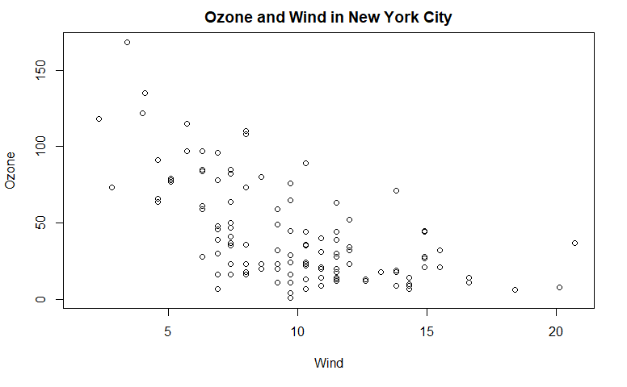

```r
library(datasets)
with(airquality, plot(Wind, Ozone))
title(main = "Ozone and Wind in New York City")  ## Add a title
```

## Base Plot with Annotation

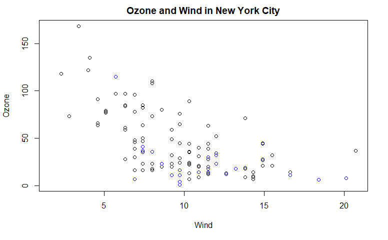

```r
with(airquality, plot(Wind, Ozone, main = "Ozone and Wind in New York City"))
with(subset(airquality, Month == 5), points(Wind, Ozone, col = "blue"))
```

## Base Plot with Annotation

```r
with(airquality, plot(Wind, Ozone, main = "Ozone and Wind in New York City", type = "n"))
with(subset(airquality, Month == 5), points(Wind, Ozone, col = "blue"))
```

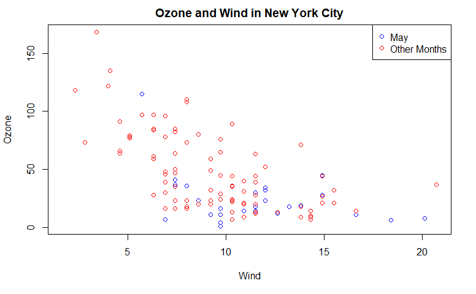

```r
with(subset(airquality, Month != 5), points(Wind, Ozone, col = "red"))
legend("topright", pch = 1, col = c("blue", "red"), legend = c("May", "Other Months"))
```

## Base Plot with Regression Line

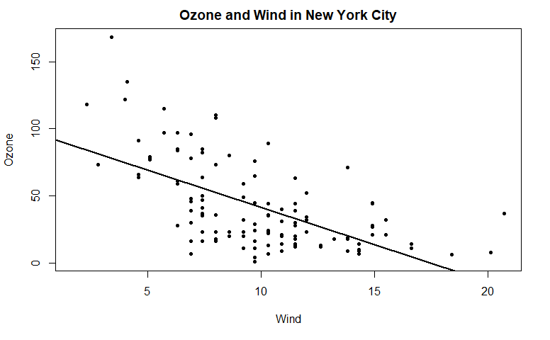

```r
with(airquality, plot(Wind, Ozone, main = "Ozone and Wind in New York City", pch = 20))
model <- lm(Ozone ~ Wind, airquality)
abline(model, lwd = 2)
```

## Multiple Base Plots

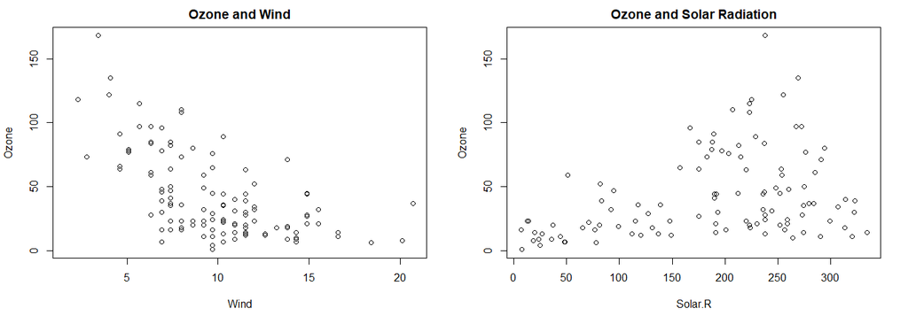

```r
par(mfrow = c(1, 2))
with(airquality, {
    plot(Wind, Ozone, main = "Ozone and Wind")
    plot(Solar.R, Ozone, main = "Ozone and Solar Radiation")
})
```

## Multiple Base Plots

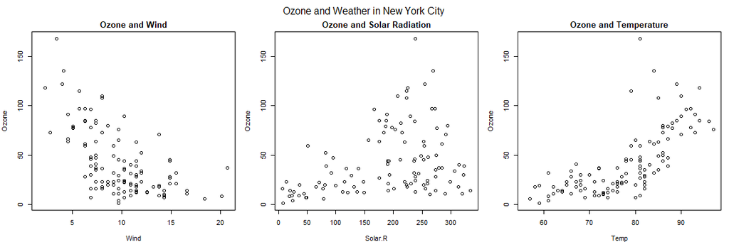

```r
par(mfrow = c(1, 3), mar = c(4, 4, 2, 1), oma = c(0, 0, 2, 0))
with(airquality, {
    plot(Wind, Ozone, main = "Ozone and Wind")
    plot(Solar.R, Ozone, main = "Ozone and Solar Radiation")
    plot(Temp, Ozone, main = "Ozone and Temperature")
    mtext("Ozone and Weather in New York City", outer = TRUE)
})
```

## Summary

- Plots in the base plotting system are created by calling successive R functions to “build up” a plot
- Plotting occurs in two stages:
  - Creation of a plot
  - Annotation of a plot (adding lines, points, text, legends)
- The base plotting system is very flexible and offers a high degree of control over plotting

Ex)

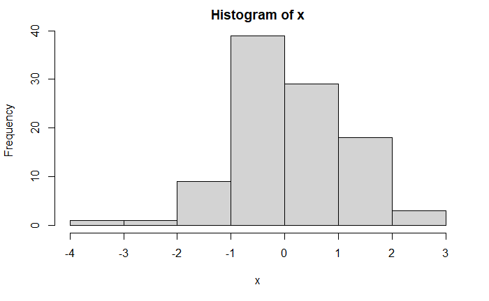

```r
x <- rnorm(100)
hist(x)
y <- rnorm(100)
par(mar = c(4,4,2,2))
```

```r
plot(x,y, pch = 18)
title("Scatterplot")
```

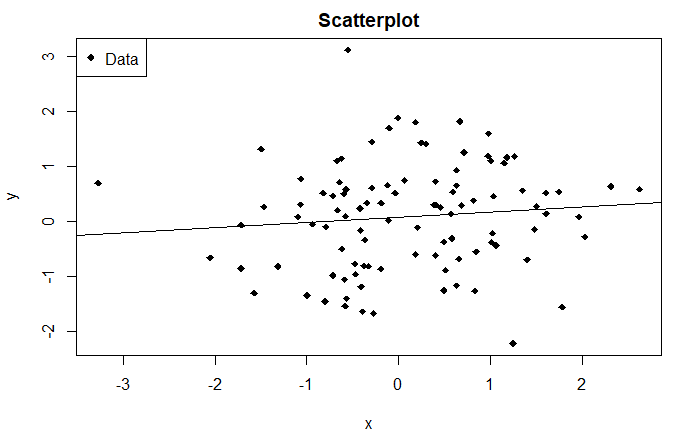

```r
legend("topleft", legend = "Data", pch=18)
fit <- lm(y~x)
abline(fit)
```

```
points> require(stats) # for rnorm

points> plot(-4:4, -4:4, type = "n")  # setting up coord. system

points> points(rnorm(200), rnorm(200), col = "red")

points> points(rnorm(100)/2, rnorm(100)/2, col = "blue", cex = 1.5)

points> op <- par(bg = "light blue")

points> x <- seq(0, 2*pi, len = 51)

points> ## something "between type='b' and type='o'":
points> plot(x, sin(x), type = "o", pch = 21, bg = par("bg"), col = "blue", cex = .6,
points+  main = 'plot(..., type="o", pch=21, bg=par("bg"))')
```

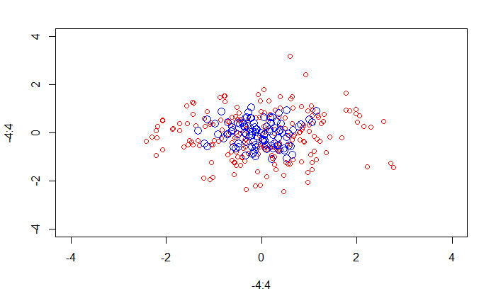

```
points> par(op)

points> ## Not run:
points> ##D ## The figure was produced by calls like
points> ##D png("pch.png", height = 0.7, width = 7, res = 100, units = "in")
points> ##D par(mar = rep(0,4))
points> ##D plot(c(-1, 26), 0:1, type = "n", axes = FALSE)
points> ##D text(0:25, 0.6, 0:25, cex = 0.5)
points> ##D points(0:25, rep(0.3, 26), pch = 0:25, bg = "grey")
points> ## End(Not run)
points>
points> ##-------- Showing all the extra & some char graphics symbols ---------
points> pchShow <-
points+   function(extras = c("*",".", "o","O","0","+","-","|","%","#"),
points+            cex = 3, ## good for both .Device=="postscript" and "x11"
points+            col = "red3", bg = "gold", coltext = "brown", cextext = 1.2,
points+            main = paste("plot symbols :  points (...  pch = *, cex =",
points+                         cex,")"))
points+   {
points+     nex <- length(extras)
points+     np  <- 26 + nex
points+     ipch <- 0:(np-1)
points+     k <- floor(sqrt(np))
points+     dd <- c(-1,1)/2
points+     rx <- dd + range(ix <- ipch %/% k)
points+     ry <- dd + range(iy <- 3 + (k-1)- ipch %% k)
points+     pch <- as.list(ipch) # list with integers & strings
points+     if(nex > 0) pch[26+ 1:nex] <- as.list(extras)
points+     plot(rx, ry, type = "n", axes  =  FALSE, xlab = "", ylab = "", main = main)
points+     abline(v = ix, h = iy, col = "lightgray", lty = "dotted")
points+     for(i in 1:np) {
points+       pc <- pch[[i]]
points+       ## 'col' symbols with a 'bg'-colored interior (where available) :
points+       points(ix[i], iy[i], pch = pc, col = col, bg = bg, cex = cex)
points+       if(cextext > 0)
points+           text(ix[i] - 0.3, iy[i], pc, col = coltext, cex = cextext)
points+     }
points+   }

points> pchShow()
```

[figure not shown]

```
points> pchShow(c("o","O","0"), cex = 2.5)
```

[figure not shown]

```
points> pchShow(NULL, cex = 4, cextext = 0, main = NULL)
```

[figure not shown]

```
points> ## No test:
points> ## ------------ test code for various pch specifications -------------
points> # Try this in various font families (including Hershey)
points> # and locales.  Use sign = -1 asserts we want Latin-1.
points> # Standard cases in a MBCS locale will not plot the top half.
points> TestChars <- function(sign = 1, font = 1, ...)
points+ {
points+    MB <- l10n_info()$MBCS
points+    r <- if(font == 5) { sign <- 1; c(32:126, 160:254)
points+        } else if(MB) 32:126 else 32:255
points+    if (sign == -1) r <- c(32:126, 160:255)
points+    par(pty = "s")
points+    plot(c(-1,16), c(-1,16), type = "n", xlab = "", ylab = "",
points+         xaxs = "i", yaxs = "i",
points+         main = sprintf("sign = %d, font = %d", sign, font))
points+    grid(17, 17, lty = 1) ; mtext(paste("MBCS:", MB))
points+    for(i in r) try(points(i%%16, i%/%16, pch = sign*i, font = font,...))
points+ }

points> TestChars()
```

[figure not shown]

```
points> try(TestChars(sign = -1))
```

[figure not shown]

```
points> TestChars(font = 5)  # Euro might be at 160 (0+10*16).
```

[figure not shown]

```
points>                      # macOS has apple at 240 (0+15*16).
points> try(TestChars(-1, font = 2))  # bold
```

[figure not shown]

```
points> ## End(No test)
points>
points>
```

[figure not shown]

```r
example(points)
```

## The Lattice Plotting System

The lattice plotting system is implemented using the following packages:

- *lattice*: contains code for producing Trellis graphics, which are independent of the “base” graphics system; includes functions like `xyplot`, `bwplot`, `levelplot`
- *grid*: implements a different graphing system independent of the “base” system; the *lattice* package builds on top of *grid*
  - We seldom call functions from the *grid* package directly
- The lattice plotting system does not have a “two-phase” aspect with separate plotting and annotation like in base plotting
- All plotting/annotation is done at once with a single function call

## Lattice Functions

- `xyplot`: this is the main function for creating scatterplots
- `bwplot`: box-and-whiskers plots (“boxplots”)
- `histogram`: histograms
- `stripplot`: like a boxplot but with actual points
- `dotplot`: plot dots on “violin strings”
- `splom`: scatterplot matrix; like `pairs` in base plotting system
- `levelplot`, `contourplot`: for plotting “image” data

## Lattice Functions

Lattice functions generally take a formula for their first argument, usually of the form

```r
xyplot(y ~ x | f * g, data)
```

- We use the *formula notation* here, hence the `~`.
- On the left of the ~ is the y-axis variable, on the right is the x-axis variable
- f and g are *conditioning variables* — they are optional
  - the * indicates an interaction between two variables
- The second argument is the data frame or list from which the variables in the formula should be looked up
  - If no data frame or list is passed, then the parent frame is used.
- If no other arguments are passed, there are defaults that can be used.

## Simple Lattice Plot

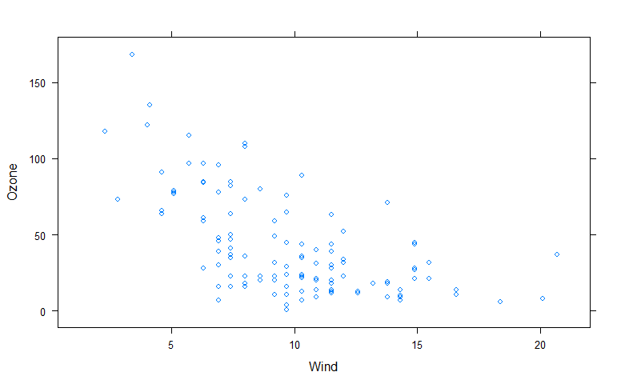

## Simple Lattice Plot

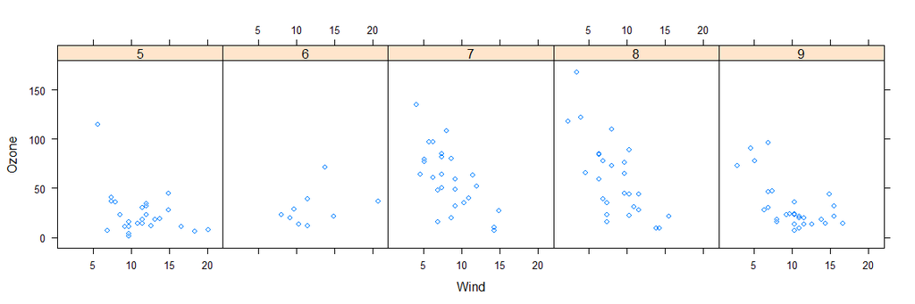

## Lattice Behavior

Lattice functions behave differently from base graphics functions in one critical way.

- Base graphics functions plot data directly to the graphics device (screen, PDF file, etc.)

- Lattice graphics functions return an object of class **trellis**

- The print methods for lattice functions actually do the work of plotting the data on the graphics device.

- Lattice functions return “plot objects” that can, in principle, be stored (but it’s usually better to just save the code + data).

- On the command line, trellis objects are *auto-printed* so that it appears the function is plotting the data

## Lattice Behavior

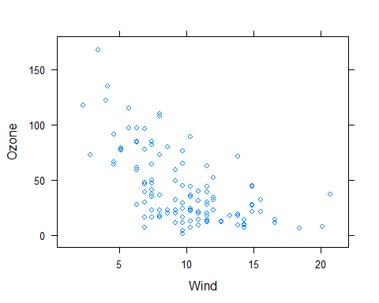

`r xyplot(Ozone ~ Wind, data = airquality) ## Auto-printing`

## Lattice Panel Functions

* Lattice functions have a **panel function** which controls what happens inside each panel of the plot.

* The *lattice* package comes with default panel functions, but you can supply your own if you want to customize what happens in each panel

* Panel functions receive the x/y coordinates of the data points in their panel (along with any optional arguments)

## Lattice Panel Functions

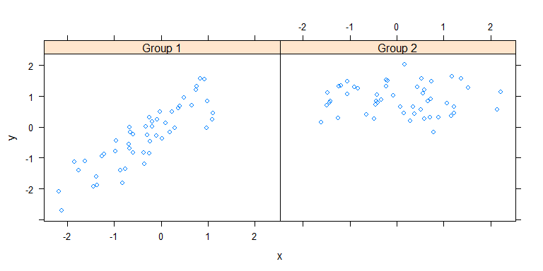

## Lattice Panel Functions

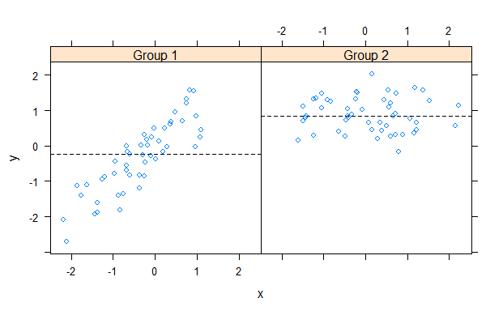

## Lattice Panel Functions: Regression line

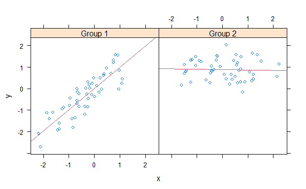

## Summary

* Lattice plots are constructed with a single function call to a core lattice function (e.g. `xyplot`)

* Aspects like margins and spacing are automatically handled and defaults are usually sufficient

* The lattice system is ideal for creating conditioning plots where you examine the same kind of plot under many different conditions

* Panel functions can be specified/customized to modify what is plotted in each of the plot panels

# GGPLOT2

## What is ggplot2?

- An implementation of *The Grammar of Graphics* by Leland Wilkinson - Written by Hadley Wickham (while he was a graduate student at Iowa State) - A “third” graphics system for R (along with **base** and **lattice**) - Available from CRAN via `install.packages()` - Web site: http://ggplot2.org (better documentation)

## What is ggplot2?

- Grammar of graphics represents an abstraction of graphics ideas/objects - Think “verb”, “noun”, “adjective” for graphics - Allows for a “theory” of graphics on which to build new graphics and graphics objects - “Shorten the distance from mind to page”

## Grammer of Graphics

### “In brief, the grammar tells us that a statistical graphic is a **mapping** from data to **aesthetic** attributes (colour, shape, size) of **geometric** objects (points, lines, bars). The plot may also contain statistical transformations of the data and is drawn on a specific coordinate system”

- from *ggplot2* book

## Plotting Systems in R: Base

- “Artist’s palette” model - Start with blank canvas and build up from there - Start with `plot` function (or similar) - Use annotation functions to add/modify (`text`, `lines`, `points`, `axis`)

## Plotting Systems in R: Base

- Convenient, mirrors how we think of building plots and analyzing data - Can’t go back once plot has started (i.e. to adjust margins); need to plan in advance - Difficult to “translate” to others once a new plot has been created (no graphical “language”) - Plot is just a series of R commands

## Plotting Systems in R: Lattice

- Plots are created with a single function call (`xyplot`, `bwplot`, etc.) - Most useful for conditioning types of plots: Looking at how $y$ changes with $x$ across levels of $z$ - Things like margins/spacing set automatically because entire plot is specified at once - Good for putting many many plots on a screen

## Plotting Systems in R: Lattice

- Sometimes awkward to specify an entire plot in a single function call - Annotation in plot is not intuitive - Use of panel functions and subscripts difficult to wield and requires intense preparation - Cannot “add” to the plot once it’s created

## Plotting Systems in R: ggplot2

- Split the difference between base and lattice - Automatically deals with spacings, text, titles but also allows you to annotate by “adding” - Superficial similarity to lattice but generally easier/more intuitive to use - Default mode makes many choices for you (but you *can* customize!)

## The Basics: `qplot()`

- Works much like the `plot` function in base graphics system - Looks for data in a data frame, similar to lattice, or in the parent environment - Plots are made up of *aesthetics* (size, shape, color) and *geoms* (points, lines)

## The Basics: `qplot()`

- Factors are important for indicating subsets of the data (if they are to have different properties); they should be **labeled** - The `qplot()` hides what goes on underneath, which is okay for most operations - `ggplot()` is the core function and very flexible for doing things `qplot()` cannot do

## Example Dataset

`r library(ggplot2) str(mpg)`

## Modifying aesthetics

`r qplot(displ, hwy, color = drv, data = mpg)`

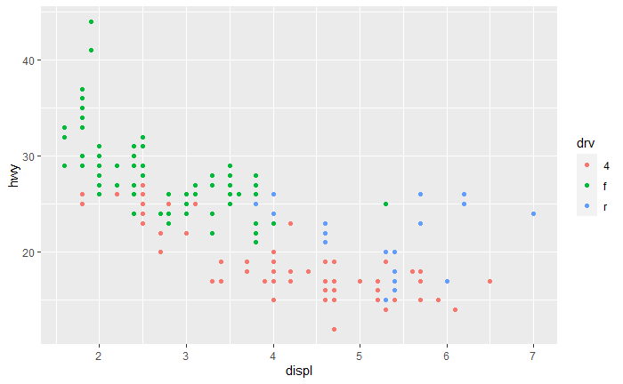

## Histograms

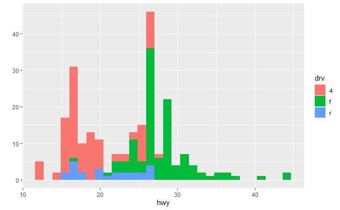

```r
qplot(hwy, data = mpg, fill = drv)
```

## Facets

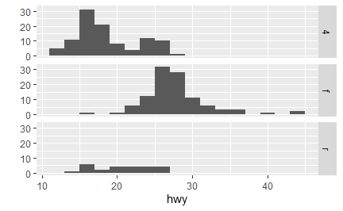

## MAACS Cohort

- Mouse Allergen and Asthma Cohort Study
- Baltimore children (aged 5—17)
- Persistent asthma, exacerbation in past year
- Study indoor environment and its relationship with asthma morbidity
- Recent publication: http://goo.gl/WqE9j8

```r
eno <- read.csv("eno.csv")
skin <- read.csv("skin.csv")
env <- read.csv("environmental.csv")
m <- merge(eno, env, by = "id")
maacs <- merge(m, skin, by = "id")
```

## Example: MAACS

```r
str(maacs)
```

[output not shown]

## Histogram of eNO

```r
qplot(log(eno), data = maacs)
```

[output not shown]

## Histogram by Group

```r
qplot(log(eno), data = maacs, fill = mopos)
```

[output not shown]

## Density Smooth

```r
qplot(log(eno), data = maacs, geom = "density")
qplot(log(eno), data = maacs, geom = "density", color = mopos)
```

[output not shown]

## Scatterplots: eNO vs. PM$_{2.5}$

```r
qplot(log(pm25), log(eno), data = maacs)
qplot(log(pm25), log(eno), data = maacs, shape = mopos)
qplot(log(pm25), log(eno), data = maacs, color = mopos)
```

[output not shown]

## Scatterplots: eNO vs. PM$_{2.5}$

```r
qplot(log(pm25), log(eno), data = maacs, color = mopos,
      geom = c("point", "smooth"), method = "lm")
```

[output not shown]

## Scatterplots: eNO vs. PM$_{2.5}$

```r
qplot(log(pm25), log(eno), data = maacs, geom = c("point", "smooth"),
      method = "lm", facets = . ~ mopos)
```

[output not shown]

## Summary of qplot()

- The `qplot()` function is the analog to `plot()` but with many built-in features
- Syntax somewhere in between base/lattice
- Produces very nice graphics, essentially publication ready (if you like the design)
- Difficult to go against the grain/customize (don’t bother; use full ggplot2 power in that case)

## Basic Components of a ggplot2 Plot

- A *data frame*
- *aesthetic mappings*: how data are mapped to color, size
- *geoms*: geometric objects like points, lines, shapes.
- *facets*: for conditional plots. (multiple panels)
- *stats*: statistical transformations like binning, quantiles, smoothing.
- *scales*: what scale an aesthetic map uses (example: male = red, female = blue).
- *coordinate system*

## Building Plots with ggplot2

- When building plots in ggplot2 (rather than using qplot) the “artist’s palette” model may be the closest analogy
- Plots are built up in layers
  - Plot the data
  - Overlay a summary
  - Metadata and annotation

## Example: BMI, PM$_{2.5}$, Asthma

- Mouse Allergen and Asthma Cohort Study
- Baltimore children (age 5-17)
- Persistent asthma, exacerbation in past year
- Does BMI (normal vs. overweight) modify the relationship between PM$_{2.5}$ and asthma symptoms?

```r
maacs <- read.csv("ggplot2_lecture2_data.csv")
```

## Basic Plot

```r
library(ggplot2)
qplot(logpm25, NocturnalSympt, data = maacs, facets = . ~ bmicat,
      geom = c("point", "smooth"), method = "lm")
```

[output not shown]

## Building Up in Layers

```r
head(maacs)
g <- ggplot(maacs, aes(logpm25, NocturnalSympt))
summary(g)
```

## No Plot Yet!

```r
g <- ggplot(maacs, aes(logpm25, NocturnalSympt))
print(g)
```

## First Plot with Point Layer

```r
g <- ggplot(maacs, aes(logpm25, NocturnalSympt))
g + geom_point()
```

[output not shown]

## Adding More Layers: Smooth

```r
g + geom_point() + geom_smooth()
g + geom_point() + geom_smooth(method = "lm")
```

[output not shown]

## Adding More Layers: Facets

```r
g + geom_point() + facet_grid(. ~ bmicat) + geom_smooth(method = "lm")
```

[output not shown]

## Modifying Aesthetics

```r
g + geom_point(color = "steelblue", size = 4, alpha = 1/2) # alpha => transparency
g + geom_point(aes(color = bmicat), size = 4, alpha = 1/2) # assigning color to be a value of a variable
```

## Modifying Labels

```r
g + geom_point(aes(color = bmicat)) + labs(title = "MAACS Cohort") +
  labs(x = expression("log " * PM[2.5]), y = "Nocturnal Symptoms")
```

## Customizing the Smooth

```r
g + geom_point(aes(color = bmicat), size = 2, alpha = 1/2) +
  geom_smooth(size = 4, linetype = 3, method = "lm", se = FALSE)
```

## Changing the Theme

```r
g + geom_point(aes(color = bmicat)) + theme_bw(base_family = "Times")
```

## A Note about Axis Limits

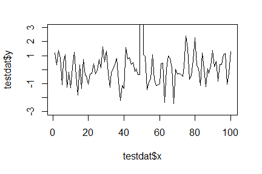

```r
testdat <- data.frame(x = 1:100, y = rnorm(100))
testdat[50,2] <- 100  ## Outlier!
plot(testdat$x, testdat$y, type = "l", ylim = c(-3,3))
```

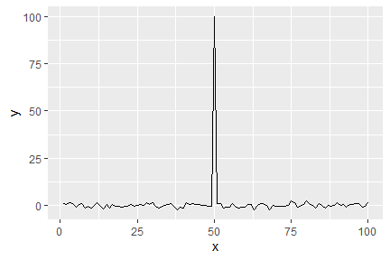

```r
g <- ggplot(testdat, aes(x = x, y = y))
g + geom_line()
```

## Axis Limits

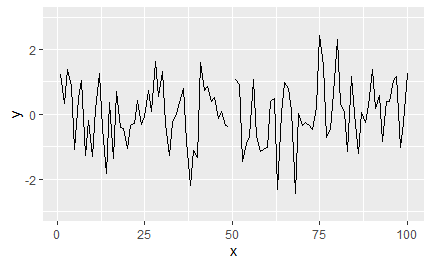

```r
g + geom_line() + ylim(-3, 3)
```

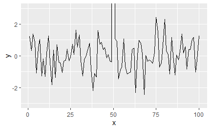

```r
g + geom_line() + coord_cartesian(ylim = c(-3, 3))
```

## More Complex Example

- How does the relationship between PM$_{2.5}$ and nocturnal symptoms vary by BMI and NO$_2$?
- Unlike our previous BMI variable, NO$_2$ is continuous
- We need to make NO$_2$ categorical so we can condition on it in the plotting
- Use the `cut()` function for this

## Making NO$_2$ Tertiles

```r
## Calculate the tertiles of the data
cutpoints <- quantile(maacs$logno2_new, seq(0, 1, length = 4), na.rm = TRUE)
## Cut the data at the tertiles and create a new factor variable
maacs$no2tert <- cut(maacs$logno2_new, cutpoints)
## See the levels of the newly created factor variable
levels(maacs$no2tert)
```

[output not shown]

## Final Plot

```r
## Setup ggplot with data frame
g <- ggplot(maacs, aes(logpm25, NocturnalSympt))
## Add layers
g + geom_point(alpha = 1/3) +
  facet_wrap(bmicat ~ no2tert, nrow = 2, ncol = 4) +
  geom_smooth(method="lm", se=FALSE, col="steelblue") +
  theme_bw(base_family = "Avenir", base_size = 10) +
  labs(x = expression("log " * PM[2.5])) +
  labs(y = "Nocturnal Symptoms") +
  labs(title = "MAACS Cohort")
```

[output not shown]

## Code for Final Plot

```r
## Setup ggplot with data frame
g <- ggplot(maacs, aes(logpm25, NocturnalSympt))
## Add layers
g + geom_point(alpha = 1/3) +
  facet_wrap(bmicat ~ no2tert, nrow = 2, ncol = 4) +
  geom_smooth(method="lm", se=FALSE, col="steelblue") +
  theme_bw(base_family = "Avenir", base_size = 10) +
  labs(x = expression("log " * PM[2.5])) +
  labs(y = "Nocturnal Symptoms") +
  labs(title = "MAACS Cohort")
```

## Summary

- ggplot2 is very powerful and flexible if you learn the “grammar” and the various elements that can be tuned/modified
- Many more types of plots can be made; explore and mess around with the package (references mentioned in Part 1 are useful)